# Project1: Music genre identification (MGI)

Author: Varun Dave

```python
! pip install chart-studio
```

## Indroduction

The dataset, both the audio and metadata, is a dump of the Free Music Archive, a free and open library directed by WFMU, the longest-running free-form radio station in the United States. Inspired by Creative Commons and the open-source software movement, the FMA provides a platform for curators, artists, and listeners to harness the potential of music sharing.

Dataset URL: https://arxiv.org/abs/1612.01840

Introducing in the few libraries for fastening music processing

```python
import pandas as pd
import numpy as np
import librosa
import librosa.display
import os
from scipy import stats
import matplotlib.pyplot as plt
import sklearn.cluster
import seaborn as sn
import datetime as dt
import IPython.display as ipd
import scipy
import cufflinks as cf
import chart_studio.tools as tls
import plotly.graph_objects as go
from chart_studio.plotly import plot, iplot
```

```python
tls.set_credentials_file(username = 'vdave95', api_key = 'PSD3d6rNgDV4oLeljXYm')
```

### Exploratory Data Analysis

Well, let's read the metadata csv file in blatant manner ;) & have a quick glimpse at top 7 rows

```python
df =  pd.read_csv(r'pdsg_musicgenre_warmup_small.csv')
df.head(7)
```

|  | Unnamed: 0 | track_id | comments | date_created | date_released | engineer | favorites | id | information | listens | ... | interest | language_code | license | listens.1 | lyricist | number | publisher | tags.2 | title.1 | file |
| --- | --- | --- | --- | --- | --- | --- | --- | --- | --- | --- | --- | --- | --- | --- | --- | --- | --- | --- | --- | --- | --- |
| 0 | 91048 | 133803 | 0.0 | 2016-03-06 14:58:50 | 2015-08-31 00:00:00 | NaN | 0.0 | 20099.0 | NaN | 13021.0 | ... | 1936.0 | NaN | Creative Commons Attribution-NonCommercial-NoD... | 1813.0 | NaN | 16.0 | NaN | [] | The Ball is Round | 133803.mp3 |
| 1 | 88664 | 130944 | 0.0 | 2016-01-16 12:08:49 | 2015-10-16 00:00:00 | NaN | 1.0 | 19720.0 | <p>L’ancien duo voix-guitares <a href="http://... | 3694.0 | ... | 816.0 | NaN | Creative Commons Attribution-NonCommercial-NoD... | 688.0 | NaN | 8.0 | NaN | [] | Bonus - Pique-assiette sentimental | 130944.mp3 |
| 2 | 2334 | 4069 | 0.0 | 2008-12-04 09:27:35 | 2008-06-09 00:00:00 | Irene Trudel | 0.0 | 897.0 | <p>A true original on the 60's Greenwich Villa... | 3052.0 | ... | 4883.0 | en | Attribution-Noncommercial-Share Alike 3.0 Unit... | 1693.0 | NaN | 4.0 | NaN | [] | Tune on Karen Dalton's Guitar | 004069.mp3 |
| 3 | 72808 | 110439 | 0.0 | 2014-10-30 18:07:49 | 2014-10-30 00:00:00 | Matt Marando | 1.0 | 17108.0 | <p> </p>\n<p class="p1">Michael Chapman is a B... | 8772.0 | ... | 1661.0 | NaN | Creative Commons Attribution-NonCommercial-NoD... | 1397.0 | NaN | 4.0 | NaN | [] | Back In Fishtown | 110439.mp3 |
| 4 | 3114 | 5157 | 0.0 | 2009-01-21 08:13:10 | 2008-05-05 00:00:00 | Irene Trudel | 1.0 | 1814.0 | <p>The amazing fretman returns to WFMU for a s... | 13128.0 | ... | 4380.0 | en | Attribution-Noncommercial-Share Alike 3.0 Unit... | 1447.0 | NaN | 2.0 | NaN | [] | Copenhagen | 005157.mp3 |
| 5 | 84394 | 125194 | 0.0 | 2015-09-19 09:01:24 | NaN | NaN | 0.0 | 18930.0 | <p>The Best of Derek Clegg 2015</p> | 18912.0 | ... | 1587.0 | NaN | Attribution-NonCommercial-ShareAlike | 1201.0 | NaN | 13.0 | NaN | [] | Found It All | 125194.mp3 |
| 6 | 57062 | 84159 | 0.0 | 2013-05-10 16:32:49 | 2008-01-01 00:00:00 | NaN | 2.0 | 14208.0 | <p>Laura Stevenson's 2008 album debut, <em>A R... | 8581.0 | ... | 1950.0 | NaN | Attribution-Noncommercial-Share Alike 3.0 Unit... | 1153.0 | NaN | 6.0 | NaN | [] | A Shine To It | 084159.mp3 |

7 rows × 55 columns

```python
# df_test = pd.read_csv(r'C:\Users\VDave\PDSG\warmup_test\warmup_test\test_set.csv')
# df_test.head(7)
```

Column Headers

```python
df.columns
```

```
Index(['Unnamed: 0', 'track_id', 'comments', 'date_created', 'date_released',
       'engineer', 'favorites', 'id', 'information', 'listens', 'producer',
       'tags', 'title', 'tracks', 'type', 'active_year_begin',
       'active_year_end', 'associated_labels', 'bio', 'comments.1',
       'date_created.1', 'favorites.1', 'id.1', 'latitude', 'location',
       'longitude', 'members', 'name', 'related_projects', 'tags.1', 'website',
       'wikipedia_page', 'split', 'subset', 'bit_rate', 'comments.2',
       'composer', 'date_created.2', 'date_recorded', 'duration',
       'favorites.2', 'genre_top', 'genres', 'genres_all', 'information.1',
       'interest', 'language_code', 'license', 'listens.1', 'lyricist',
       'number', 'publisher', 'tags.2', 'title.1', 'file'],
      dtype='object')
```

Strippin filename

```python
df['filename']  = [song.split('.')[0] for song in df['file']]
# df_test['filename']    = [song.split('.')[0] for song in df_test['file']]
```

#### Playing with wave files

Librosa loads and decodes the audio as a time series y, represented as a one-dimensional NumPy floating point array. The variable sr contains the sampling rate of y, that is, the number of samples per second of audio. By default, all audio is mixed to mono and resampled to 22050 Hz at load time. This behavior can be overridden by supplying additional arguments to librosa.load().

I have randomly selected file for each genre

hip-hop: 152543.mp3

folk: 000814.mp3

```python
y_folk, sr_folk = librosa.load('000814.wav')
print("Folk 000814.mp3")
print("Time series length:", len(y_folk))
print("Sampling rate:", sr_folk)
print("Wav file length in secs:",round(len(y_folk)/sr_folk,2))
```

```
Folk 000814.mp3
Time series length: 661250
Sampling rate: 22050
Wav file length in secs: 29.99
```

```python
y_hh, sr_hh = librosa.load('152543.wav')
print("Hip-Hop 152543.mp3")
print("Time series length:", len(y_hh))
print("Sampling rate:", sr_hh)
print("Wav file length in secs:",round(len(y_hh)/sr_hh,2))
```

```
Hip-Hop 152543.mp3
Time series length: 662402
Sampling rate: 22050
Wav file length in secs: 30.04
```

```python
df_ = pd.DataFrame(np.transpose(mfcc), columns = ["n_mfcc_{:02d}".format(i) for i in range((mfcc.shape)[0])])
df_.describe()

# df_test_ = pd.DataFrame(np.transpose(mfcc), columns = ["n_mfcc_{:02d}".format(i) for i in range((mfcc.shape)[0])])
# df_test_.describe()
```

|  | n_mfcc_00 | n_mfcc_01 | n_mfcc_02 | n_mfcc_03 | n_mfcc_04 | n_mfcc_05 | n_mfcc_06 | n_mfcc_07 | n_mfcc_08 | n_mfcc_09 | ... | n_mfcc_30 | n_mfcc_31 | n_mfcc_32 | n_mfcc_33 | n_mfcc_34 | n_mfcc_35 | n_mfcc_36 | n_mfcc_37 | n_mfcc_38 | n_mfcc_39 |
| --- | --- | --- | --- | --- | --- | --- | --- | --- | --- | --- | --- | --- | --- | --- | --- | --- | --- | --- | --- | --- | --- |
| count | 1293.000000 | 1293.000000 | 1293.000000 | 1293.000000 | 1293.000000 | 1293.000000 | 1293.000000 | 1293.000000 | 1293.000000 | 1293.000000 | ... | 1293.000000 | 1293.000000 | 1293.000000 | 1293.000000 | 1293.000000 | 1293.000000 | 1293.000000 | 1293.000000 | 1293.000000 | 1293.000000 |
| mean | -314.937561 | 195.558533 | -25.237528 | 23.456963 | 47.109238 | -16.959848 | -1.833571 | 14.715027 | -7.504394 | 2.022819 | ... | 0.480988 | -3.583944 | -4.427908 | -3.320694 | -5.627313 | -0.569856 | 0.389040 | -4.761256 | 0.078602 | 1.888352 |
| std | 26.036516 | 15.300933 | 13.521786 | 9.065399 | 7.035676 | 9.754462 | 8.035782 | 6.392054 | 6.878143 | 6.944157 | ... | 12.199276 | 10.297480 | 7.681797 | 7.179666 | 8.034293 | 9.626530 | 7.039127 | 6.907525 | 8.795776 | 10.491609 |
| min | -521.264832 | 87.940582 | -71.562485 | -1.378767 | 12.195381 | -40.986595 | -28.309580 | -4.291855 | -29.551666 | -16.012604 | ... | -27.796141 | -29.249626 | -30.698591 | -23.713829 | -25.912167 | -24.751402 | -15.922115 | -27.830826 | -22.942230 | -20.381050 |
| 25% | -331.815277 | 184.330963 | -34.142075 | 17.142014 | 42.295326 | -23.831697 | -6.961475 | 10.491774 | -12.538078 | -3.403208 | ... | -10.045862 | -11.651169 | -9.204323 | -8.323299 | -11.412750 | -7.645936 | -4.491342 | -9.514429 | -5.643476 | -4.846118 |
| 50% | -315.684937 | 194.723785 | -25.159496 | 23.190071 | 46.840591 | -16.702473 | -2.013224 | 14.875648 | -7.678402 | 2.106302 | ... | 0.486500 | -4.560189 | -4.404567 | -3.846768 | -5.928259 | -1.125881 | -0.513500 | -4.597181 | -0.735468 | 0.315203 |
| 75% | -297.165039 | 206.307938 | -16.491318 | 29.447132 | 51.759884 | -10.114782 | 3.810382 | 19.462322 | -3.083402 | 6.892017 | ... | 9.672029 | 4.153919 | 0.749955 | 1.198920 | -0.241086 | 5.381420 | 4.274149 | 0.130224 | 4.880469 | 6.096088 |
| max | -239.460815 | 239.092178 | 55.176777 | 58.772720 | 74.846451 | 10.759737 | 24.203043 | 33.591724 | 14.123709 | 27.968681 | ... | 35.249012 | 23.201260 | 16.351265 | 22.028250 | 24.466259 | 33.118488 | 28.861118 | 13.335941 | 30.446867 | 43.918350 |

8 rows × 40 columns

### Feature engineering

```python
def mfcc_extract(filename):
    n_mfcc     = 40
    hop_length = 12800

    # y -> time series; sr -> sample rate per second
    fn    = filename +".wav"
    y, sr = librosa.load(fn)

    # Compute MFCC features from the raw signal (https://en.wikipedia.org/wiki/Mel-frequency_cepstrum)
    # In sound processing, the mel-frequency cepstrum (MFC) is a representation of the short-term power spectrum of a sound,
    # based on a linear cosine transform of a log power spectrum on a nonlinear mel scale of frequency.
    mfcc = librosa.feature.mfcc(y=y, sr=sr, hop_length=hop_length, n_mfcc=n_mfcc)

    # Normalize mfcc for eliminating bias for lower frequencies
    # mfcc = librosa.util.normalize(mfcc, norm=inf, axis=0, threshold=None, fill=None)

    df_ = pd.DataFrame(np.transpose(mfcc), columns = ["n_mfcc_{:02d}".format(i) for i in range((mfcc.shape)[0])])

    return df_
```

```python
##Statisitc metric function

def statsex(df_):

    df_col = df_.columns

    stat_names = ("stat_mean","stat_mode","stat_median","stat_tmean","stat_q1","stat_q3"
        ,"stat_std","stat_var","stat_iqr","stat_min","stat_max","stat_range"
        ,"stat_skew","stat_kurtosis")

    stat_funcs = ("np.mean(df_.iloc[:,{}])"
                  ,"stats.mode(df_.iloc[:,{}])[0][0]"
                  ,"np.median(df_.iloc[:,{}])"
                  ,"stats.trim_mean(df_.iloc[:,{}],0.05)"
                  ,"np.percentile(df_.iloc[:,{}],25)"
                  ,"np.percentile(df_.iloc[:,{}],75)"
                  ,"np.std(df_.iloc[:,{}], ddof=1)"
                  ,"np.var(df_.iloc[:,{}], ddof=1)"
                  ,"stats.iqr(df_.iloc[:,{}])"
                  ,"np.min(df_.iloc[:,{}])"
                  ,"np.max(df_.iloc[:,{}])"
                  ,"np.ptp(df_.iloc[:,{}])"
                  ,"stats.skew(df_.iloc[:,{}])"
                  ,"stats.kurtosis(df_.iloc[:,{}])")


    #Creating a dictionary for the purpose of aggregating features across the attributes mentioned in cols with stat_funcs
    feature_space  = {}

    for col in range(len(df_col)):
        for name,func in zip (stat_names,stat_funcs):
            key = df_col[col] + "_" + name
            feature_space[key] = eval(func.format(col))

    return feature_space
```

Clubbing mfcc_extract with statsex and df table. So here, we take the df table, extract the filename as a separate column for each filename we capture the mfcc from thee wav file using the mfcc_extract function and apply statsex to it to give us a dictionary that needs to be appended to df table as feature set.

```python
app = []

for file in df['filename']:
    file_fe_space = statsex(mfcc_extract(file))
    app.append(file_fe_space)

mfcc_fe_space = pd.DataFrame.from_dict(app)
mfcc_fe_space.head(10)
```

|  | n_mfcc_00_stat_iqr | n_mfcc_00_stat_kurtosis | n_mfcc_00_stat_max | n_mfcc_00_stat_mean | n_mfcc_00_stat_median | n_mfcc_00_stat_min | n_mfcc_00_stat_mode | n_mfcc_00_stat_q1 | n_mfcc_00_stat_q3 | n_mfcc_00_stat_range | ... | n_mfcc_39_stat_median | n_mfcc_39_stat_min | n_mfcc_39_stat_mode | n_mfcc_39_stat_q1 | n_mfcc_39_stat_q3 | n_mfcc_39_stat_range | n_mfcc_39_stat_skew | n_mfcc_39_stat_std | n_mfcc_39_stat_tmean | n_mfcc_39_stat_var |
| --- | --- | --- | --- | --- | --- | --- | --- | --- | --- | --- | --- | --- | --- | --- | --- | --- | --- | --- | --- | --- | --- |
| 0 | 44.853287 | 11.264496 | -176.189392 | -250.317627 | -245.149689 | -501.172424 | -501.172424 | -268.464447 | -223.611160 | 324.983032 | ... | 0.097824 | -13.719210 | -13.719210 | -4.927096 | 8.699060 | 48.630592 | 1.060177 | 10.548653 | 2.070333 | 111.274071 |
| 1 | 44.581112 | 20.602895 | -135.317749 | -214.127167 | -205.457611 | -560.691772 | -560.691772 | -232.909592 | -188.328480 | 425.374023 | ... | -3.091195 | -22.116634 | -22.116634 | -7.626511 | 2.114278 | 32.472572 | -0.365758 | 7.316643 | -3.071393 | 53.533260 |
| 2 | 40.337654 | 0.247236 | -226.259445 | -306.598145 | -304.778748 | -404.104523 | -404.104523 | -324.999069 | -284.661415 | 177.845078 | ... | -5.372460 | -13.297592 | -13.297592 | -8.567506 | -2.592938 | 23.659969 | 0.923295 | 4.734169 | -5.272286 | 22.412354 |
| 3 | 44.853092 | 12.672739 | -150.814468 | -228.872177 | -230.655518 | -469.504639 | -469.504639 | -248.394669 | -203.541576 | 318.690186 | ... | -3.231848 | -21.821592 | -21.821592 | -6.799815 | 0.001537 | 26.880095 | -0.966524 | 5.028864 | -3.755027 | 25.289473 |
| 4 | 35.861534 | 1.816073 | -281.603668 | -383.171600 | -386.259613 | -467.662964 | -467.662964 | -399.679802 | -363.818268 | 186.059296 | ... | -4.174699 | -16.962677 | -16.962677 | -7.678195 | 4.128617 | 27.444796 | 0.054251 | 7.642869 | -2.896903 | 58.413445 |
| 5 | 42.478260 | 13.697038 | -122.383896 | -184.967316 | -179.671631 | -411.445374 | -411.445374 | -202.962650 | -160.484390 | 289.061462 | ... | 8.238270 | -5.338882 | -5.338882 | 3.127190 | 12.651755 | 26.270761 | -0.226367 | 5.633884 | 8.104645 | 31.740650 |
| 6 | 56.930317 | 1.877581 | -175.890076 | -250.471115 | -234.891174 | -439.220337 | -439.220337 | -271.428627 | -214.498310 | 263.330261 | ... | 2.664183 | -21.618776 | -21.618776 | -1.601616 | 7.510054 | 42.734116 | -0.001286 | 9.019177 | 3.370754 | 81.345566 |
| 7 | 23.106869 | 30.250847 | -175.955261 | -209.884216 | -202.596863 | -473.103851 | -473.103851 | -215.388332 | -192.281464 | 297.148590 | ... | -1.451982 | -15.695689 | -15.695689 | -4.423790 | 1.155683 | 26.511204 | -0.304431 | 5.467497 | -1.777268 | 29.893528 |
| 8 | 43.877411 | 16.373372 | -363.050171 | -426.295868 | -419.682587 | -709.501343 | -709.501343 | -440.581696 | -396.704285 | 346.451172 | ... | 0.844837 | -11.812703 | -11.812703 | -1.894460 | 8.626234 | 36.354362 | 0.577068 | 8.152761 | 2.854183 | 66.467506 |
| 9 | 49.943035 | 10.185981 | -142.614105 | -209.188049 | -203.175156 | -462.545319 | -462.545319 | -226.839825 | -176.896790 | 319.931213 | ... | 0.440698 | -17.922165 | -17.922165 | -3.926301 | 4.286274 | 38.048180 | 0.117993 | 8.281810 | -0.040203 | 68.588371 |

10 rows × 560 columns

```python
test_app = []
test_path = 'C:/Users/VDave/PDSG/warmup_test/warmup_test/'

for file in df_test['filename']:
    file_path = test_path + file
    file_fe_space = statsex(mfcc_extract(file_path))
    test_app.append(file_fe_space)

mfcc_fe_test_space = pd.DataFrame.from_dict(test_app)
mfcc_fe_test_space.head(10)
```

[output not shown]

Putting mfcc_fe_space into the df dataframe

```python
# df = pd.concat([df, mfcc_fe_space], axis=1)
df.columns
```

```
Index(['Unnamed: 0', 'track_id', 'comments', 'date_created', 'date_released',
       'engineer', 'favorites', 'id', 'information', 'listens', 'producer',
       'tags', 'title', 'tracks', 'type', 'active_year_begin',
       'active_year_end', 'associated_labels', 'bio', 'comments.1',
       'date_created.1', 'favorites.1', 'id.1', 'latitude', 'location',
       'longitude', 'members', 'name', 'related_projects', 'tags.1', 'website',
       'wikipedia_page', 'split', 'subset', 'bit_rate', 'comments.2',
       'composer', 'date_created.2', 'date_recorded', 'duration',
       'favorites.2', 'genre_top', 'genres', 'genres_all', 'information.1',
       'interest', 'language_code', 'license', 'listens.1', 'lyricist',
       'number', 'publisher', 'tags.2', 'title.1', 'file', 'filename'],
      dtype='object')
```

Change in amplitude of a signal in file can be effective to describe a music genre

```python
def change_amplitude(filename):

#   y -> time series; sr -> sample rate per second
    fn    = filename+'.wav'
    y, sr = librosa.load(fn)
    delta_y = [abs(y[i]-y[i-1]) for i in range(1,len(y))]
    return np.mean(delta_y)

df['delta_y'] = [change_amplitude(i) for i in df['filename']]
```

### Feature data-type description

```python
df.describe()
```

[output not shown]

### Train-test split

```python
from sklearn.model_selection import train_test_split
X = mfcc_fe_space
y = df['genre_top']
```

```python
## Hot encode label
from sklearn import preprocessing
le = preprocessing.LabelEncoder()
y = le.fit_transform(y)
X_train, X_test, y_train, y_test = train_test_split(X, y, test_size=0.33, random_state=42)
```

### Hypothesis Testing

Minimize Redundance: Look at the overlap across the groups within a feature space.

Maximize Relevance: See if a feature or subset of features can better explain the distinction of cohorts with respect to music genres.

|  | Feature | Score_x | Score_y | folk_diff_hiph |
| --- | --- | --- | --- | --- |
| 13 | n_mfcc_00_stat_var | 60106.180375 | 131374.855386 | 71268.675011 |
| 27 | n_mfcc_01_stat_var | 21474.277551 | 47602.721856 | 26128.444304 |
| 41 | n_mfcc_02_stat_var | 16052.098790 | 32410.386495 | 16358.287705 |
| 55 | n_mfcc_03_stat_var | 4277.948083 | 10654.445012 | 6376.496928 |
| 69 | n_mfcc_04_stat_var | 2554.740399 | 7350.485505 | 4795.745106 |
| 83 | n_mfcc_05_stat_var | 3865.237191 | 7246.266700 | 3381.029510 |
| 97 | n_mfcc_06_stat_var | 1765.121819 | 4194.805988 | 2429.684169 |
| 111 | n_mfcc_07_stat_var | 1179.286891 | 3109.908472 | 1930.621582 |
| 139 | n_mfcc_09_stat_var | 1231.286626 | 2961.749738 | 1730.463112 |
| 125 | n_mfcc_08_stat_var | 1870.733011 | 3509.080457 | 1638.347447 |
| 153 | n_mfcc_10_stat_var | 1037.419268 | 2273.445500 | 1236.026231 |
| 405 | n_mfcc_28_stat_var | 2494.513116 | 1305.958884 | 1188.554232 |
| 307 | n_mfcc_21_stat_var | 2264.788777 | 1202.273413 | 1062.515364 |
| 293 | n_mfcc_20_stat_var | 2083.059838 | 1062.630833 | 1020.429005 |
| 335 | n_mfcc_23_stat_var | 1857.770861 | 904.506164 | 953.264697 |

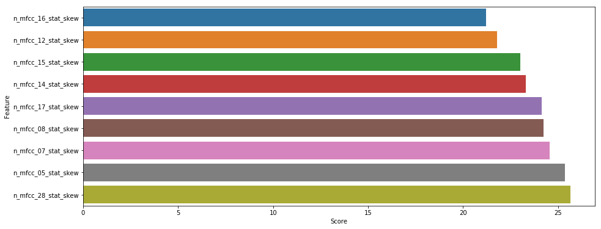

```python
# https://pythonhosted.org/bob.learn.em/guide.html#gaussian-mixture-models
#Concat the X and y

df_ht = pd.concat([pd.Series(le.inverse_transform(y_train), name='genres'),X_train.reset_index()], axis=1,  ignore_index=False)
df_ht.drop('index', axis=1, inplace = True)

# #Distribute the data as per genre labels
folk = df_ht[df_ht['genres']== 'Folk']
hiph = df_ht[df_ht['genres']== 'Hip-Hop']
folk.drop('genres', axis=1, inplace=True)
hiph.drop('genres', axis=1, inplace=True)

folk.head()

## Minkowskimatrices
def minkowski_mat(df,p):
    min_mat = []
    for idx,col in enumerate(df.columns):
        mean = np.full((df.shape[0],1),df.mean()[idx])
        vals = df.iloc[:,idx]
        dist = scipy.spatial.distance.minkowski(mean, vals, p=p, w=None)
        min_mat.append([col, dist])

    return min_mat

## Fe_score as per genres
folk_dist_mat = minkowski_mat(folk,1)
hiph_dist_mat = minkowski_mat(hiph,1)

# Creating a dataframe for looking for feature explaining max centering within a genre
folk_dist_pd = pd.DataFrame(folk_dist_mat, columns=['Feature','Score'])
hiph_dist_pd = pd.DataFrame(hiph_dist_mat, columns=['Feature','Score'])

## Ordering variance within folk
folk_ord = folk_dist_pd.sort_values(by='Score', ascending=True)
sn.barplot(y = 'Feature',x = 'Score',data = folk_ord.iloc[:9,:])

## Ordering variance within hiph
hiph_ord = hiph_dist_pd.sort_values(by='Score', ascending=True)
sn.barplot(y = 'Feature',x ='Score',data = hiph_ord.iloc[:9,:])

## Comparing variance across genres
folk_hiph_pd = pd.merge(folk_dist_pd, hiph_dist_pd,how='inner',on = 'Feature')
folk_hiph_pd['folk_diff_hiph'] = abs(folk_hiph_pd['Score_x'] - folk_hiph_pd['Score_y'])
folk_hiph_ord = folk_hiph_pd.sort_values(by = 'folk_diff_hiph', ascending=False)
# sn.barplot(y = 'Feature',x ='folk_diff_hiph',data = folk_hiph_ord.iloc[:4,:])
folk_hiph_ord.head(15)
# figmm = px.bar(folk_hiph_ord.iloc[:4,:], x="folk_diff_hiph", y="Feature", orientation='h')
# figmm.show()
```

```python
from sklearn.naive_bayes import GaussianNB
gnb = GaussianNB().fit(X_train, y_train)
y_pred = gnb.predict(X_test)

from sklearn.metrics import accuracy_score

acc = accuracy_score(y_test,y_pred)

fe_score = []
for col in X_train.columns:
    Xtrain = X_train.drop([col], axis =1)
    Xtest = X_test.drop([col], axis =1)
    gnb_b = GaussianNB().fit(Xtrain, y_train)
    ypred = gnb_b.predict(Xtest)
    score  = acc - accuracy_score(y_test,ypred)
    if score != 0:
        fe_score.append([col, np.round(score,4)*100])
```

```python
fes = pd.DataFrame(fe_score, columns=['Feature','Score'])
empty = []
for i in fes['Score']:
    if i > 0:
        empty.append('Positive')
    elif i < 0:
        empty.append('Negative')

fes['Impact'] = empty

import plotly.express as px
fig_fr = px.bar(fes.sort_values(by='Score', ascending = True), x="Score", y="Feature",
                text = 'Score', orientation='h', color = 'Impact',
               color_discrete_sequence=['lightgoldenrodyellow','palegreen'])
fig_fr.show()
```

[interactive chart not shown]

```python
# https://people.eecs.berkeley.edu/~jordan/kernels/0521813972c05_p111-139.pdf
# https://pdfs.semanticscholar.org/b6a3/e0028d99439ce2741d0e147b6e9a34bc4267.pdf
# Prazen based classification to explain GNB
```

### Machine Learning

```python
## GNB
from sklearn.naive_bayes import GaussianNB
gnb = GaussianNB().fit(X_train, y_train)
y_pred = gnb.predict(X_test)
```

```python
## Model Evaluation
from sklearn.metrics import confusion_matrix
from sklearn.metrics import classification_report
from sklearn.metrics import accuracy_score

print(confusion_matrix(y_test,y_pred))
print(classification_report(y_test,y_pred))
print(accuracy_score(y_test,y_pred))
```

```
[[32  3]
 [ 1 30]]
              precision    recall  f1-score   support

           0       0.97      0.91      0.94        35
           1       0.91      0.97      0.94        31

   micro avg       0.94      0.94      0.94        66
   macro avg       0.94      0.94      0.94        66
weighted avg       0.94      0.94      0.94        66

0.9393939393939394
```

```python
# ### Test set predictions
# y_pred = le.inverse_transform(gnb.predict(mfcc_fe_test_space))
# results = pd.concat([df_test['track_id'], pd.Series(y_pred, name ="Predicted_Genre")], axis=1)
# results.to_csv('results.csv')
```

```python
from sklearn.metrics import accuracy_score, log_loss
from sklearn.neighbors import KNeighborsClassifier
from sklearn.svm import SVC, LinearSVC, NuSVC
from sklearn.tree import DecisionTreeClassifier
from sklearn.ensemble import RandomForestClassifier, AdaBoostClassifier, GradientBoostingClassifier
from sklearn.naive_bayes import GaussianNB
from sklearn.discriminant_analysis import LinearDiscriminantAnalysis
from sklearn.discriminant_analysis import QuadraticDiscriminantAnalysis

classifiers = [
    KNeighborsClassifier(3),
    SVC(kernel="rbf", C=0.025, probability=True),
    NuSVC(probability=True),
    DecisionTreeClassifier(),
    RandomForestClassifier(),
    AdaBoostClassifier(),
    GradientBoostingClassifier(),
    GaussianNB(),
    LinearDiscriminantAnalysis(),
    QuadraticDiscriminantAnalysis()]

# Logging for Visual Comparison
log_cols=["Classifier", "Accuracy", "Log Loss"]
log = pd.DataFrame(columns=log_cols)

for clf in classifiers:
    clf.fit(X_train, y_train)
    name = clf.__class__.__name__

    print("="*30)
    print(name)

    print('****Results****')
    y_pred = clf.predict(X_test)
    acc = accuracy_score(y_test, y_pred)
    print("Accuracy: {:.4%}".format(acc))

    conf_mat = [1 if abs(yp - yt) == 0 else 0 for yp,yt in zip(y_pred,y_test)]
    print("Number of accurately predicted instances out of a total %d points : %d"
          % (len(y_test),sum(conf_mat)))

    train_predictions = clf.predict_proba(X_test)
    ll = log_loss(y_test, train_predictions)
    print("Log Loss: {}".format(ll))

    log_entry = pd.DataFrame([[name, acc*100, ll]], columns=log_cols)
    log = log.append(log_entry)

print("="*30)
```

```
==============================
KNeighborsClassifier
****Results****
Accuracy: 66.6667%
Number of accurately predicted instances out of a total 66 points : 44
Log Loss: 3.065421951527753
==============================
SVC
****Results****
Accuracy: 46.9697%
Number of accurately predicted instances out of a total 66 points : 31
Log Loss: 0.6938188647977002
```

```
==============================
NuSVC
****Results****
Accuracy: 46.9697%
Number of accurately predicted instances out of a total 66 points : 31
Log Loss: 0.7976198140523566
==============================
DecisionTreeClassifier
****Results****
Accuracy: 78.7879%
Number of accurately predicted instances out of a total 66 points : 52
Log Loss: 7.326407114071963
==============================
RandomForestClassifier
****Results****
Accuracy: 86.3636%
Number of accurately predicted instances out of a total 66 points : 57
Log Loss: 0.3799157811291326
```

```
==============================
AdaBoostClassifier
****Results****
Accuracy: 89.3939%
Number of accurately predicted instances out of a total 66 points : 59
Log Loss: 0.5014827398818258
==============================
GradientBoostingClassifier
****Results****
Accuracy: 75.7576%
Number of accurately predicted instances out of a total 66 points : 50
Log Loss: 1.0217670470625118
==============================
GaussianNB
****Results****
Accuracy: 93.9394%
Number of accurately predicted instances out of a total 66 points : 62
Log Loss: 1.7365883282362444
==============================
LinearDiscriminantAnalysis
****Results****
Accuracy: 80.3030%
Number of accurately predicted instances out of a total 66 points : 53
Log Loss: 2.3950020244267725
==============================
QuadraticDiscriminantAnalysis
****Results****
Accuracy: 53.0303%
Number of accurately predicted instances out of a total 66 points : 35
Log Loss: 16.222758609730775
==============================
```

```python
log.sort_values(by = 'Accuracy',ascending = True, inplace=True)
```

```python
log['Is it above benchmark?'] = ['No' if i < 80 else 'Yes' for i in log['Accuracy']]
log['Acc'] = [round(i,2) if i >80 else '' for i in log['Accuracy']]

fig_md = px.bar(log, x="Accuracy", y="Classifier",
                text = 'Acc', orientation='h', color = 'Is it above benchmark?',
               color_discrete_sequence=['Grey','Teal'])
fig_md.show()

# sn.set_color_codes("muted")
# sn.barplot(x='Log Loss', y='Classifier', data=log, color="g")

# plt.xlabel('Log Loss')
# plt.title('Classifier Log Loss')
# plt.show()
```

[output not shown]

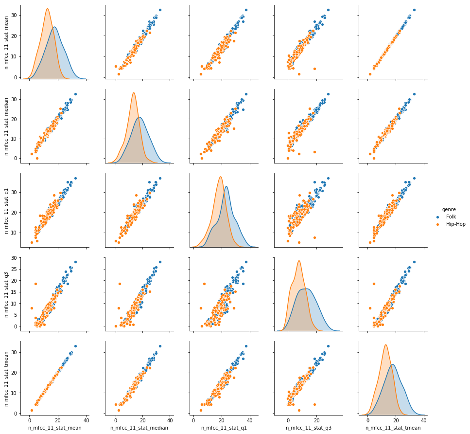

```python
## Inferences
imp_fes = fes[fes['Score']>0]['Feature']  #Selecting the imp feature based on feature releveance
X_bar   = X.filter(items=imp_fes, axis=1) #Filtering imp fe from the rest
X_bar   = X_bar.abs()
df_inf  = X_bar.join(pd.Series(le.inverse_transform(y), name='genre'))   #bringing in genres
sn.pairplot(df_inf, hue = 'genre')
```

```python
# fi = go.Figure(go.Scatterternary({
#     'mode': 'markers',
#     'a': df_inf['n_mfcc_11_stat_mean'],
#     'b': df_inf['n_mfcc_11_stat_median'],
#     'c': df_inf['n_mfcc_11_stat_q1'],
#     'text': df_inf['genre'],
#     'marker': {
#         'symbol': 100,
#         'color': '#DB7365',
#         'size': 14,
#         'line': { 'width': 2 }
#     }
# }))

# def makeAxis(title, tickangle):
#     return {
#       'title': title,
#       'titlefont': { 'size': 20 },
#       'tickangle': tickangle,
#       'tickfont': { 'size': 15 },
#       'tickcolor': 'rgba(0,0,0,0)',
#       'ticklen': 5,
#       'showline': True,
#       'showgrid': True
#     }

# fi.update_layout({
#     'ternary': {
#         'sum': 100,
#         'aaxis': makeAxis('Mean', 0),
#         'baxis': makeAxis('<br>Median', 45),
#         'caxis': makeAxis('<br>Quartile 1', -45)
#     },
#     'annotations': [{
#       'showarrow': False,
#       'text': '11th MFCC Bin Feature Plot',
#         'x': 0.5,
#         'y': 1.3,
#         'font': { 'size': 15 }
#     }]
# })

# fi.show()

# fi = px.scatter(df_inf, x="n_mfcc_11_stat_mean", y="n_mfcc_11_stat_median", color="genre")
# fi.show()

# fi = make_subplots(rows=1, cols=2)
# fi.add_trace(go.Scatter(x=df_inf['n_mfcc_11_stat_mean'], y=df_inf['n_mfcc_11_stat_median'], mode='markers'),
#                         row = 1, col = 1)
# fi.add_trace(go.Scatter(x=df_inf['n_mfcc_11_stat_mean'], y=df_inf['n_mfcc_11_stat_q1'], mode='markers'),
#                         row = 1, col = 2)
# fi.update_xaxes(title_text='Mean',ticks="inside",tickcolor='green', ticklen=5)
# fi.update_yaxes(title_text='', ticks="inside",tickcolor='green', ticklen=5, col =1)
# fi.update_layout(title="Gaussian Surface for Relevant Feature Subset")
# fi.show()

fi = px.scatter_3d(df_inf, x='n_mfcc_11_stat_mean', y='n_mfcc_11_stat_median', z='n_mfcc_11_stat_q1',
              color='genre')
fi.show()


# fig5 = go.Figure(data=go.Scatter(y=infer_mfcc.iloc[11], x=list(range(infer_mfcc.shape[1]))))
# fig5.update_layout(
#     title='Relevant Feature Space',xaxis_title='Time Frame',
#     yaxis_title='11th Bin of Mel-frequency Cepstral Coefficients (MFCCs)')

# fig5.show()
```

[interactive chart not shown]